# FRAUD DETECTION

Parallel Coordinates: Useful for visualizing multivariate data.

Dendrograms: Show hierarchical clustering relationships.

Density Plots: Illustrate the distribution of data points.

Lollipop Charts: Display differences between two points.

Waffle Charts: Depict proportions using squares or rectangles.

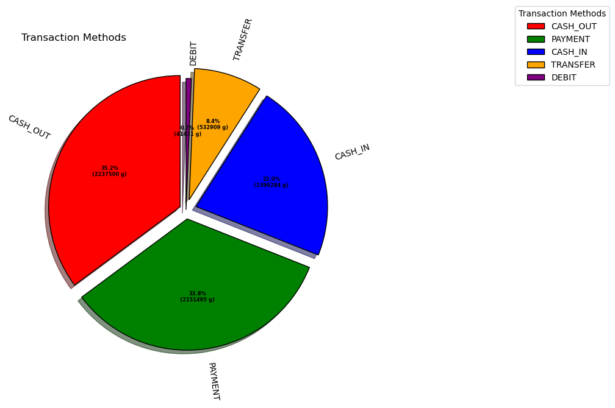

```python
# # Define payment method labels and colors
payment_method = ['CASH_OUT', 'PAYMENT', 'CASH_IN', 'TRANSFER', 'DEBIT']

#set colors to be used for Pie Chart
colors = ['red', 'green', 'blue', 'orange', 'purple']

new_df = {
    'type': valList,  # Example: [CASH_OUT, PAYMENT, CASH_IN, TRANSFER, DEBIT]
}

# wedge property is used to set the border of the pie chart (i.e Line width is for the thickness of circumference and edgecolor
# is to set the color )
wp = {'linewidth': 1, 'edgecolor': "black"}

#This is to seperate the pie chart
explode = (0.05, 0.07, 0.08, 0.08, 0.0)

# # Create a pie chart
def func(pct, allvalues):
    absolute = int(pct / 100.*np.sum(allvalues))
    return "{:.1f}%\n({:d} g)".format(pct, absolute)

fig, ax = plt.subplots(figsize=(10, 7))
wedges, texts, autotexts = ax.pie(new_df['type'],
                                  autopct=lambda pct: func(pct, new_df['type']),
                                  explode=explode,
                                  labels=payment_method,
                                  shadow=True,
                                  colors=colors,
                                  startangle=90,
                                  wedgeprops=wp, radius=1, rotatelabels=True)

# # Add legend
ax.legend(payment_method,
          title="Transaction Methods",
          loc="right",
          bbox_to_anchor=(1.5, 0.7, 0.3, 0.6))

# # Customize autotexts
plt.setp(autotexts, size=6, weight="bold")

# # Set title
ax.set_title("Transaction Methods", loc="left")

# # Show the plot
plt.show()
```

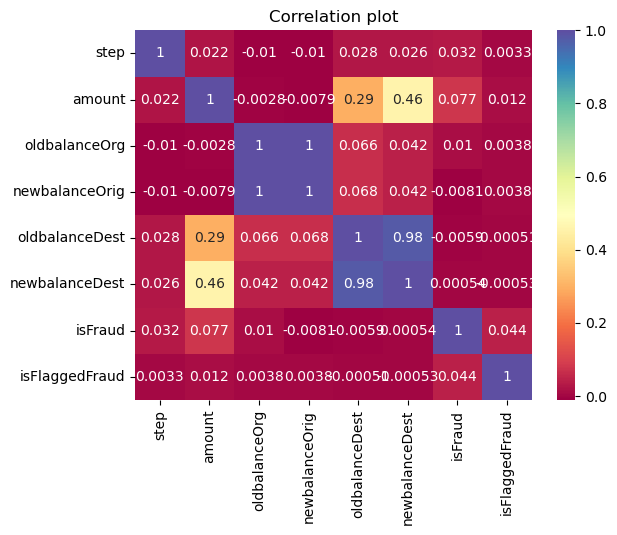

```python
sns.heatmap(df[['step', 'amount', 'oldbalanceOrg', 'newbalanceOrig', 'oldbalanceDest', 'newbalanceDest', 'isFraud',
       'isFlaggedFraud']].corr(), annot=True, cmap=sns.color_palette("Spectral", as_cmap=True), cbar=True)
plt.title("Correlation plot")
plt.show()
```

This is the visualization of the correlation from before. There is a multi-correlation(i.e (newbalanceorig, oldbalanceorig), (newbalancedest, oldbalancedest)

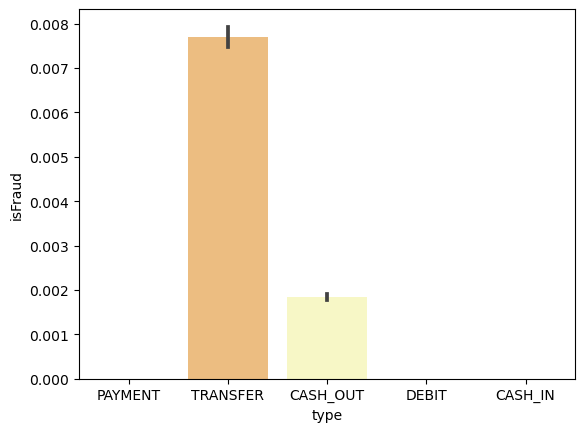

```python
sns.barplot(x=df['type'], y=df['isFraud'], palette="Spectral")
plt.show()
```

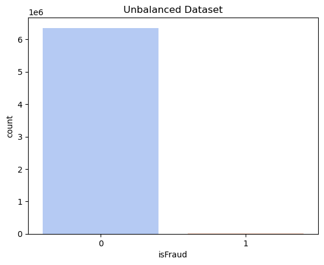

```python
sns.countplot(x=df['isFraud'], palette="coolwarm")
plt.title("Unbalanced Dataset")
plt.show()
```

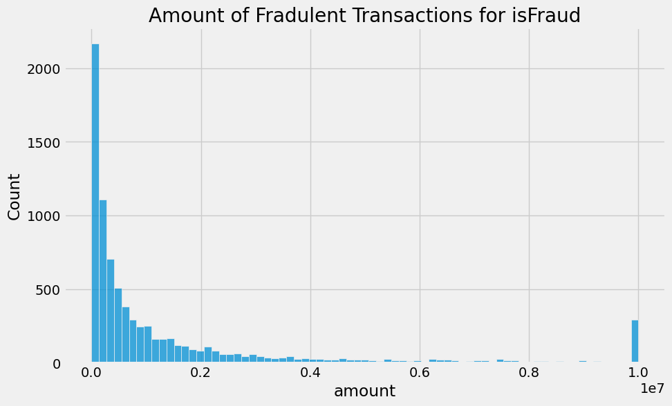

```python
figure = plt.subplots(figsize = (10, 6))

plt.subplot()
ax = sns.histplot(data=df[df['isFraud']==1],x='amount', palette="coolwarm")
plt.title('Amount of Fradulent Transactions for isFraud')

plt.show()
```

# FEATURE EXTRACTION/ SELECTION

```python
df['type'].unique()
```

```
array(['PAYMENT', 'TRANSFER', 'CASH_OUT', 'DEBIT', 'CASH_IN'],
      dtype=object)
```

```python
df[(df['type'] == "CASH_OUT") & (df['isFraud'] == 1)]
```

|  | step | type | amount | nameOrig | oldbalanceOrg | newbalanceOrig | nameDest | oldbalanceDest | newbalanceDest | isFraud | isFlaggedFraud |
| --- | --- | --- | --- | --- | --- | --- | --- | --- | --- | --- | --- |
| 3 | 1 | CASH_OUT | 181.00 | C840083671 | 181.00 | 0.0 | C38997010 | 21182.00 | 0.00 | 1 | 0 |
| 252 | 1 | CASH_OUT | 2806.00 | C2101527076 | 2806.00 | 0.0 | C1007251739 | 26202.00 | 0.00 | 1 | 0 |
| 681 | 1 | CASH_OUT | 20128.00 | C1118430673 | 20128.00 | 0.0 | C339924917 | 6268.00 | 12145.85 | 1 | 0 |
| 724 | 1 | CASH_OUT | 416001.33 | C749981943 | 0.00 | 0.0 | C667346055 | 102.00 | 9291619.62 | 1 | 0 |
| 970 | 1 | CASH_OUT | 1277212.77 | C467632528 | 1277212.77 | 0.0 | C716083600 | 0.00 | 2444985.19 | 1 | 0 |
| ... | ... | ... | ... | ... | ... | ... | ... | ... | ... | ... | ... |
| 6362611 | 742 | CASH_OUT | 63416.99 | C994950684 | 63416.99 | 0.0 | C1662241365 | 276433.18 | 339850.17 | 1 | 0 |
| 6362613 | 743 | CASH_OUT | 1258818.82 | C1436118706 | 1258818.82 | 0.0 | C1240760502 | 503464.50 | 1762283.33 | 1 | 0 |
| 6362615 | 743 | CASH_OUT | 339682.13 | C786484425 | 339682.13 | 0.0 | C776919290 | 0.00 | 339682.13 | 1 | 0 |
| 6362617 | 743 | CASH_OUT | 6311409.28 | C1162922333 | 6311409.28 | 0.0 | C1365125890 | 68488.84 | 6379898.11 | 1 | 0 |
| 6362619 | 743 | CASH_OUT | 850002.52 | C1280323807 | 850002.52 | 0.0 | C873221189 | 6510099.11 | 7360101.63 | 1 | 0 |

4116 rows × 11 columns

```python
df[(df['type'] == "CASH_OUT") & (df['isFraud'] == 0)]
```

|  | step | type | amount | nameOrig | oldbalanceOrg | newbalanceOrig | nameDest | oldbalanceDest | newbalanceDest | isFraud | isFlaggedFraud |
| --- | --- | --- | --- | --- | --- | --- | --- | --- | --- | --- | --- |
| 15 | 1 | CASH_OUT | 229133.94 | C905080434 | 15325.00 | 0.0 | C476402209 | 5083.00 | 51513.44 | 0 | 0 |
| 42 | 1 | CASH_OUT | 110414.71 | C768216420 | 26845.41 | 0.0 | C1509514333 | 288800.00 | 2415.16 | 0 | 0 |
| 47 | 1 | CASH_OUT | 56953.90 | C1570470538 | 1942.02 | 0.0 | C824009085 | 70253.00 | 64106.18 | 0 | 0 |
| 48 | 1 | CASH_OUT | 5346.89 | C512549200 | 0.00 | 0.0 | C248609774 | 652637.00 | 6453430.91 | 0 | 0 |
| 51 | 1 | CASH_OUT | 23261.30 | C2072313080 | 20411.53 | 0.0 | C2001112025 | 25742.00 | 0.00 | 0 | 0 |
| ... | ... | ... | ... | ... | ... | ... | ... | ... | ... | ... | ... |
| 6362306 | 718 | CASH_OUT | 169291.34 | C1569237054 | 26919.00 | 0.0 | C342077848 | 2684602.16 | 2853893.50 | 0 | 0 |
| 6362313 | 718 | CASH_OUT | 111963.72 | C1438119383 | 4514.00 | 0.0 | C99772923 | 154925.27 | 266888.99 | 0 | 0 |
| 6362317 | 718 | CASH_OUT | 317177.48 | C857156502 | 170.00 | 0.0 | C784108220 | 345042.13 | 662219.61 | 0 | 0 |
| 6362320 | 718 | CASH_OUT | 159188.22 | C691808084 | 3859.00 | 0.0 | C1818183087 | 0.00 | 159188.22 | 0 | 0 |
| 6362321 | 718 | CASH_OUT | 186273.84 | C102120699 | 168046.00 | 0.0 | C1515639522 | 24893.67 | 211167.51 | 0 | 0 |

2233384 rows × 11 columns

```python
df[(df['type'] == "PAYMENT") & (df['isFraud'] == 0)]
```

|  | step | type | amount | nameOrig | oldbalanceOrg | newbalanceOrig | nameDest | oldbalanceDest | newbalanceDest | isFraud | isFlaggedFraud |
| --- | --- | --- | --- | --- | --- | --- | --- | --- | --- | --- | --- |
| 0 | 1 | PAYMENT | 9839.64 | C1231006815 | 170136.0 | 160296.36 | M1979787155 | 0.0 | 0.0 | 0 | 0 |
| 1 | 1 | PAYMENT | 1864.28 | C1666544295 | 21249.0 | 19384.72 | M2044282225 | 0.0 | 0.0 | 0 | 0 |
| 4 | 1 | PAYMENT | 11668.14 | C2048537720 | 41554.0 | 29885.86 | M1230701703 | 0.0 | 0.0 | 0 | 0 |
| 5 | 1 | PAYMENT | 7817.71 | C90045638 | 53860.0 | 46042.29 | M573487274 | 0.0 | 0.0 | 0 | 0 |
| 6 | 1 | PAYMENT | 7107.77 | C154988899 | 183195.0 | 176087.23 | M408069119 | 0.0 | 0.0 | 0 | 0 |
| ... | ... | ... | ... | ... | ... | ... | ... | ... | ... | ... | ... |
| 6362312 | 718 | PAYMENT | 8178.01 | C1213413071 | 11742.0 | 3563.99 | M1112540487 | 0.0 | 0.0 | 0 | 0 |
| 6362314 | 718 | PAYMENT | 17841.23 | C1045048098 | 10182.0 | 0.00 | M1878955882 | 0.0 | 0.0 | 0 | 0 |
| 6362316 | 718 | PAYMENT | 1022.91 | C1203084509 | 12.0 | 0.00 | M675916850 | 0.0 | 0.0 | 0 | 0 |
| 6362318 | 718 | PAYMENT | 4109.57 | C673558958 | 5521.0 | 1411.43 | M1126011651 | 0.0 | 0.0 | 0 | 0 |
| 6362319 | 718 | PAYMENT | 8634.29 | C642813806 | 518802.0 | 510167.71 | M747723689 | 0.0 | 0.0 | 0 | 0 |

2151495 rows × 11 columns

```python
df[(df['type'] == "PAYMENT") & (df['isFraud'] == 1)]
```

|  | step | type | amount | nameOrig | oldbalanceOrg | newbalanceOrig | nameDest | oldbalanceDest | newbalanceDest | isFraud | isFlaggedFraud |
| --- | --- | --- | --- | --- | --- | --- | --- | --- | --- | --- | --- |

```python
df[(df['type'] == "DEBIT") & (df['isFraud'] == 0)]
```

|  | step | type | amount | nameOrig | oldbalanceOrg | newbalanceOrig | nameDest | oldbalanceDest | newbalanceDest | isFraud | isFlaggedFraud |
| --- | --- | --- | --- | --- | --- | --- | --- | --- | --- | --- | --- |
| 9 | 1 | DEBIT | 5337.77 | C712410124 | 41720.0 | 36382.23 | C195600860 | 41898.00 | 40348.79 | 0 | 0 |
| 10 | 1 | DEBIT | 9644.94 | C1900366749 | 4465.0 | 0.00 | C997608398 | 10845.00 | 157982.12 | 0 | 0 |
| 21 | 1 | DEBIT | 9302.79 | C1566511282 | 11299.0 | 1996.21 | C1973538135 | 29832.00 | 16896.70 | 0 | 0 |
| 22 | 1 | DEBIT | 1065.41 | C1959239586 | 1817.0 | 751.59 | C515132998 | 10330.00 | 0.00 | 0 | 0 |
| 41 | 1 | DEBIT | 5758.59 | C1466917878 | 32604.0 | 26845.41 | C1297685781 | 209699.00 | 16997.22 | 0 | 0 |
| ... | ... | ... | ... | ... | ... | ... | ... | ... | ... | ... | ... |
| 6362247 | 718 | DEBIT | 2063.08 | C397492133 | 328612.0 | 326548.92 | C1557979171 | 1312720.98 | 1314784.06 | 0 | 0 |
| 6362254 | 718 | DEBIT | 425.65 | C1835928822 | 4046.0 | 3620.35 | C701975669 | 3009282.73 | 3009708.38 | 0 | 0 |
| 6362282 | 718 | DEBIT | 1636.03 | C761454361 | 83120.0 | 81483.97 | C355970563 | 8393318.02 | 8394954.05 | 0 | 0 |
| 6362303 | 718 | DEBIT | 2148.99 | C1909103796 | 49632.0 | 47483.01 | C1931871221 | 66241.39 | 68390.38 | 0 | 0 |
| 6362323 | 718 | DEBIT | 1864.24 | C49652609 | 20426.0 | 18561.76 | C1799009964 | 188746.00 | 190610.24 | 0 | 0 |

41432 rows × 11 columns

```python
df[(df['type'] == "DEBIT") & (df['isFraud'] == 1)]
```

|  | step | type | amount | nameOrig | oldbalanceOrg | newbalanceOrig | nameDest | oldbalanceDest | newbalanceDest | isFraud | isFlaggedFraud |
| --- | --- | --- | --- | --- | --- | --- | --- | --- | --- | --- | --- |

```python
df[(df['type'] == "TRANSFER") & (df['isFraud'] == 0)]
```

|  | step | type | amount | nameOrig | oldbalanceOrg | newbalanceOrig | nameDest | oldbalanceDest | newbalanceDest | isFraud | isFlaggedFraud |
| --- | --- | --- | --- | --- | --- | --- | --- | --- | --- | --- | --- |
| 19 | 1 | TRANSFER | 215310.30 | C1670993182 | 705.00 | 0.00 | C1100439041 | 22425.00 | 0.00 | 0 | 0 |
| 24 | 1 | TRANSFER | 311685.89 | C1984094095 | 10835.00 | 0.00 | C932583850 | 6267.00 | 2719172.89 | 0 | 0 |
| 58 | 1 | TRANSFER | 62610.80 | C1976401987 | 79114.00 | 16503.20 | C1937962514 | 517.00 | 8383.29 | 0 | 0 |
| 78 | 1 | TRANSFER | 42712.39 | C283039401 | 10363.39 | 0.00 | C1330106945 | 57901.66 | 24044.18 | 0 | 0 |
| 79 | 1 | TRANSFER | 77957.68 | C207471778 | 0.00 | 0.00 | C1761291320 | 94900.00 | 22233.65 | 0 | 0 |
| ... | ... | ... | ... | ... | ... | ... | ... | ... | ... | ... | ... |
| 6362211 | 718 | TRANSFER | 92746.73 | C587921214 | 5051.00 | 0.00 | C930436926 | 279931.86 | 372678.59 | 0 | 0 |
| 6362223 | 718 | TRANSFER | 76507.70 | C1157171835 | 13161.00 | 0.00 | C720176528 | 274281.30 | 350789.00 | 0 | 0 |
| 6362229 | 718 | TRANSFER | 14563.03 | C936960472 | 20705.00 | 6141.97 | C1924752944 | 153878.31 | 168441.35 | 0 | 0 |
| 6362256 | 718 | TRANSFER | 139144.25 | C1264043726 | 7075.00 | 0.00 | C2093369248 | 49040158.93 | 49179303.19 | 0 | 0 |
| 6362322 | 718 | TRANSFER | 82096.45 | C614459560 | 13492.00 | 0.00 | C855350324 | 0.00 | 82096.45 | 0 | 0 |

528812 rows × 11 columns

```python
df[(df['type'] == "TRANSFER") & (df['isFraud'] == 1)]
```

|  | step | type | amount | nameOrig | oldbalanceOrg | newbalanceOrig | nameDest | oldbalanceDest | newbalanceDest | isFraud | isFlaggedFraud |
| --- | --- | --- | --- | --- | --- | --- | --- | --- | --- | --- | --- |
| 2 | 1 | TRANSFER | 181.00 | C1305486145 | 181.00 | 0.0 | C553264065 | 0.0 | 0.0 | 1 | 0 |
| 251 | 1 | TRANSFER | 2806.00 | C1420196421 | 2806.00 | 0.0 | C972765878 | 0.0 | 0.0 | 1 | 0 |
| 680 | 1 | TRANSFER | 20128.00 | C137533655 | 20128.00 | 0.0 | C1848415041 | 0.0 | 0.0 | 1 | 0 |
| 969 | 1 | TRANSFER | 1277212.77 | C1334405552 | 1277212.77 | 0.0 | C431687661 | 0.0 | 0.0 | 1 | 0 |
| 1115 | 1 | TRANSFER | 35063.63 | C1364127192 | 35063.63 | 0.0 | C1136419747 | 0.0 | 0.0 | 1 | 0 |
| ... | ... | ... | ... | ... | ... | ... | ... | ... | ... | ... | ... |
| 6362610 | 742 | TRANSFER | 63416.99 | C778071008 | 63416.99 | 0.0 | C1812552860 | 0.0 | 0.0 | 1 | 0 |
| 6362612 | 743 | TRANSFER | 1258818.82 | C1531301470 | 1258818.82 | 0.0 | C1470998563 | 0.0 | 0.0 | 1 | 0 |
| 6362614 | 743 | TRANSFER | 339682.13 | C2013999242 | 339682.13 | 0.0 | C1850423904 | 0.0 | 0.0 | 1 | 0 |
| 6362616 | 743 | TRANSFER | 6311409.28 | C1529008245 | 6311409.28 | 0.0 | C1881841831 | 0.0 | 0.0 | 1 | 0 |
| 6362618 | 743 | TRANSFER | 850002.52 | C1685995037 | 850002.52 | 0.0 | C2080388513 | 0.0 | 0.0 | 1 | 0 |

4097 rows × 11 columns

```python
df[(df['type'] == "CASH_IN") & (df['isFraud'] == 1)]
```

|  | step | type | amount | nameOrig | oldbalanceOrg | newbalanceOrig | nameDest | oldbalanceDest | newbalanceDest | isFraud | isFlaggedFraud |
| --- | --- | --- | --- | --- | --- | --- | --- | --- | --- | --- | --- |

```python
df[(df['type'] == "CASH_IN") & (df['isFraud'] == 0)]
```

|  | step | type | amount | nameOrig | oldbalanceOrg | newbalanceOrig | nameDest | oldbalanceDest | newbalanceDest | isFraud | isFlaggedFraud |
| --- | --- | --- | --- | --- | --- | --- | --- | --- | --- | --- | --- |
| 389 | 1 | CASH_IN | 143236.26 | C1862994526 | 0.00 | 143236.26 | C1688019098 | 608932.17 | 97263.78 | 0 | 0 |
| 390 | 1 | CASH_IN | 228451.89 | C1614133563 | 143236.26 | 371688.15 | C2083562754 | 719678.38 | 1186556.81 | 0 | 0 |
| 391 | 1 | CASH_IN | 35902.49 | C839771540 | 371688.15 | 407590.65 | C2001112025 | 49003.30 | 0.00 | 0 | 0 |
| 392 | 1 | CASH_IN | 232953.64 | C1037163664 | 407590.65 | 640544.28 | C33524623 | 1172672.27 | 1517262.16 | 0 | 0 |
| 393 | 1 | CASH_IN | 65912.95 | C180316302 | 640544.28 | 706457.23 | C1330106945 | 104198.26 | 24044.18 | 0 | 0 |
| ... | ... | ... | ... | ... | ... | ... | ... | ... | ... | ... | ... |
| 6362253 | 718 | CASH_IN | 188888.89 | C1459052107 | 51838.00 | 240726.89 | C1955750585 | 0.00 | 0.00 | 0 | 0 |
| 6362271 | 718 | CASH_IN | 27919.60 | C562982749 | 2413.00 | 30332.60 | C240654881 | 512791.59 | 484871.98 | 0 | 0 |
| 6362279 | 718 | CASH_IN | 78988.38 | C886862695 | 204464.00 | 283452.38 | C262804200 | 108724.19 | 29735.81 | 0 | 0 |
| 6362298 | 718 | CASH_IN | 18000.26 | C50108853 | 63409.00 | 81409.26 | C204102272 | 28088.61 | 10088.34 | 0 | 0 |
| 6362315 | 718 | CASH_IN | 96239.74 | C759614959 | 101281.00 | 197520.74 | C1766719169 | 151109.37 | 54869.63 | 0 | 0 |

1399284 rows × 11 columns

FROM THE ABOVE INFORMATION 'CASHOUT' HAS THE HIGHEST NO OF FRAUD ACTIVITIES FOLLOWED BY 'TRANSFER' WHILE THE REST HAVE NONE

```python
df[['step', 'amount', 'oldbalanceOrg', 'newbalanceOrig', 'oldbalanceDest', 'newbalanceDest', 'isFraud',
       'isFlaggedFraud']].corr()
```

|  | step | amount | oldbalanceOrg | newbalanceOrig | oldbalanceDest | newbalanceDest | isFraud | isFlaggedFraud |
| --- | --- | --- | --- | --- | --- | --- | --- | --- |
| step | 1.000000 | 0.022373 | -0.010058 | -0.010299 | 0.027665 | 0.025888 | 0.031578 | 0.003277 |
| amount | 0.022373 | 1.000000 | -0.002762 | -0.007861 | 0.294137 | 0.459304 | 0.076688 | 0.012295 |
| oldbalanceOrg | -0.010058 | -0.002762 | 1.000000 | 0.998803 | 0.066243 | 0.042029 | 0.010154 | 0.003835 |
| newbalanceOrig | -0.010299 | -0.007861 | 0.998803 | 1.000000 | 0.067812 | 0.041837 | -0.008148 | 0.003776 |
| oldbalanceDest | 0.027665 | 0.294137 | 0.066243 | 0.067812 | 1.000000 | 0.976569 | -0.005885 | -0.000513 |
| newbalanceDest | 0.025888 | 0.459304 | 0.042029 | 0.041837 | 0.976569 | 1.000000 | 0.000535 | -0.000529 |
| isFraud | 0.031578 | 0.076688 | 0.010154 | -0.008148 | -0.005885 | 0.000535 | 1.000000 | 0.044109 |
| isFlaggedFraud | 0.003277 | 0.012295 | 0.003835 | 0.003776 | -0.000513 | -0.000529 | 0.044109 | 1.000000 |

# FEATURE SELECTION/EXTRACTION

```python
new_df = df.drop(['oldbalanceOrg'], axis=1)
new_df['type'] = new_df['type'].map({'PAYMENT': 1, 'TRANSFER': 2, 'CASH_OUT': 3, 'DEBIT': 4, 'CASH_IN': 5})
new_df = new_df.drop(['newbalanceOrig'], axis=1)
new_df = new_df.drop(['nameOrig'], axis=1)
new_df = new_df.drop(['nameDest'], axis=1)
new_df
```

|  | step | type | amount | oldbalanceDest | newbalanceDest | isFraud | isFlaggedFraud |
| --- | --- | --- | --- | --- | --- | --- | --- |
| 0 | 1 | 1 | 9839.64 | 0.00 | 0.00 | 0 | 0 |
| 1 | 1 | 1 | 1864.28 | 0.00 | 0.00 | 0 | 0 |
| 2 | 1 | 2 | 181.00 | 0.00 | 0.00 | 1 | 0 |
| 3 | 1 | 3 | 181.00 | 21182.00 | 0.00 | 1 | 0 |
| 4 | 1 | 1 | 11668.14 | 0.00 | 0.00 | 0 | 0 |
| ... | ... | ... | ... | ... | ... | ... | ... |
| 6362615 | 743 | 3 | 339682.13 | 0.00 | 339682.13 | 1 | 0 |
| 6362616 | 743 | 2 | 6311409.28 | 0.00 | 0.00 | 1 | 0 |
| 6362617 | 743 | 3 | 6311409.28 | 68488.84 | 6379898.11 | 1 | 0 |
| 6362618 | 743 | 2 | 850002.52 | 0.00 | 0.00 | 1 | 0 |
| 6362619 | 743 | 3 | 850002.52 | 6510099.11 | 7360101.63 | 1 | 0 |

6362620 rows × 7 columns

# BALANCING THE DATASET

```python
normal_transactions = new_df[new_df['isFraud'] == 0]
fraud_transactions = new_df[new_df['isFraud'] == 1]
print(normal_transactions.shape, fraud_transactions.shape)
```

```
(6354407, 7) (8213, 7)
```

The data is unbalanced just lke the visualsation from before so we have to normalize the data by making the no of fraud transactions and normal transactions equal

```python
normal_transactions = normal_transactions.sample(8213)
```

```python
normal_transactions.shape
```

```
(8213, 7)
```

```python
new_df = pd.concat([normal_transactions, fraud_transactions], axis=0)
new_df.head(15)
```

|  | step | type | amount | oldbalanceDest | newbalanceDest | isFraud | isFlaggedFraud |
| --- | --- | --- | --- | --- | --- | --- | --- |
| 4149870 | 303 | 5 | 315243.07 | 1.620991e+08 | 1.617838e+08 | 0 | 0 |
| 503207 | 20 | 1 | 25692.70 | 0.000000e+00 | 0.000000e+00 | 0 | 0 |
| 5956892 | 405 | 5 | 120674.07 | 8.336007e+05 | 7.129266e+05 | 0 | 0 |
| 2620421 | 208 | 1 | 2682.30 | 0.000000e+00 | 0.000000e+00 | 0 | 0 |
| 904981 | 43 | 3 | 131287.68 | 8.075070e+03 | 1.393628e+05 | 0 | 0 |
| 1415105 | 139 | 3 | 394390.32 | 0.000000e+00 | 3.943903e+05 | 0 | 0 |
| 4377696 | 311 | 5 | 214505.28 | 6.132928e+05 | 3.987875e+05 | 0 | 0 |
| 2447101 | 203 | 1 | 21798.09 | 0.000000e+00 | 0.000000e+00 | 0 | 0 |
| 338563 | 16 | 2 | 181181.29 | 1.643916e+06 | 1.825097e+06 | 0 | 0 |
| 3685613 | 276 | 5 | 162270.77 | 0.000000e+00 | 0.000000e+00 | 0 | 0 |
| 439365 | 18 | 3 | 54473.58 | 0.000000e+00 | 5.447358e+04 | 0 | 0 |
| 736867 | 38 | 5 | 374725.11 | 0.000000e+00 | 0.000000e+00 | 0 | 0 |
| 3775399 | 280 | 3 | 360261.55 | 9.429982e+05 | 1.303260e+06 | 0 | 0 |
| 2770829 | 213 | 3 | 106173.00 | 0.000000e+00 | 1.061730e+05 | 0 | 0 |
| 732863 | 37 | 1 | 6337.01 | 0.000000e+00 | 0.000000e+00 | 0 | 0 |

```python
new_df.tail(15)
```

|  | step | type | amount | oldbalanceDest | newbalanceDest | isFraud | isFlaggedFraud |
| --- | --- | --- | --- | --- | --- | --- | --- |
| 6362605 | 742 | 3 | 54652.46 | 0.00 | 54652.46 | 1 | 0 |
| 6362606 | 742 | 2 | 303846.74 | 0.00 | 0.00 | 1 | 0 |
| 6362607 | 742 | 3 | 303846.74 | 343660.89 | 647507.63 | 1 | 0 |
| 6362608 | 742 | 2 | 258355.42 | 0.00 | 0.00 | 1 | 0 |
| 6362609 | 742 | 3 | 258355.42 | 25176.67 | 283532.09 | 1 | 0 |
| 6362610 | 742 | 2 | 63416.99 | 0.00 | 0.00 | 1 | 0 |
| 6362611 | 742 | 3 | 63416.99 | 276433.18 | 339850.17 | 1 | 0 |
| 6362612 | 743 | 2 | 1258818.82 | 0.00 | 0.00 | 1 | 0 |
| 6362613 | 743 | 3 | 1258818.82 | 503464.50 | 1762283.33 | 1 | 0 |
| 6362614 | 743 | 2 | 339682.13 | 0.00 | 0.00 | 1 | 0 |
| 6362615 | 743 | 3 | 339682.13 | 0.00 | 339682.13 | 1 | 0 |
| 6362616 | 743 | 2 | 6311409.28 | 0.00 | 0.00 | 1 | 0 |
| 6362617 | 743 | 3 | 6311409.28 | 68488.84 | 6379898.11 | 1 | 0 |
| 6362618 | 743 | 2 | 850002.52 | 0.00 | 0.00 | 1 | 0 |
| 6362619 | 743 | 3 | 850002.52 | 6510099.11 | 7360101.63 | 1 | 0 |

# TRAINING TESTING AND SPLITTING

Methods of generating a validation include: Hold-out validation, Stratified Hold-out validation, k-fold Cross, and Leave one out Validation. But i will make use of Hold out validation and if after that each set does not get similar distribution(which would help generate a better model then) the stratified Hold-out validation will resolve this issue

```python
indep_varX = new_df.drop(['isFraud'], axis=1)
dep_varY= new_df['isFraud']
```

```python
from sklearn.model_selection import train_test_split as tts
train_new_dfX, test_new_dfX, train_new_dfY, test_new_dfY = tts(indep_varX, dep_varY, random_state=0, test_size=0.2, stratify=None)
```

```python
print("shape of train_new_dfX: ", train_new_dfX.shape)
print("shape of test_new_dfX: ", test_new_dfX.shape)
print("shape of train_new_dfY: ", train_new_dfY.shape)
print("shape of test_new_dfX: ", test_new_dfY.shape)
```

```
shape of train_new_dfX:  (13140, 6)
shape of test_new_dfX:  (3286, 6)
shape of train_new_dfY:  (13140,)
shape of test_new_dfX:  (3286,)
```

```python
from sklearn.model_selection import train_test_split as tts
train_x, val_x, train_y, val_y = tts(train_new_dfX, train_new_dfY, test_size=0.2, random_state=0, stratify=None)
```

```python
print("shape of training set: ", train_x.shape, train_y.shape)

print("shape of validation set: ", val_x.shape, val_y.shape)

print("shape of test set: ", test_new_dfX.shape, test_new_dfY.shape)
```

```
shape of training set:  (10512, 6) (10512,)
shape of validation set:  (2628, 6) (2628,)
shape of test set:  (3286, 6) (3286,)
```

```python
train_y.value_counts()/ len(train_y)
```

```
isFraud
1    0.500856
0    0.499144
Name: count, dtype: float64
```

```python
val_y.value_counts()/ len(val_y)
```

```
isFraud
0    0.508371
1    0.491629
Name: count, dtype: float64
```

```python
train_new_dfY.value_counts()/ len(train_new_dfY)
```

```
isFraud
0    0.500989
1    0.499011
Name: count, dtype: float64
```

Since the distribution is slightly off then stratified hloud-out method will be used. though the issue with this method is we wont get enough training data but the solution to this k-fold cross

```python
from sklearn.model_selection import train_test_split as tts
train_new_dfX, test_new_dfX, train_new_dfY, test_new_dfY = tts(indep_varX, dep_varY, random_state=0, test_size=0.2, stratify=dep_varY)
```

```python
from sklearn.model_selection import train_test_split as tts
train_x, val_x, train_y, val_y = tts(train_new_dfX, train_new_dfY, test_size=0.2, random_state=42, stratify=train_new_dfY)
```

```python
print("shape of training set: ", train_x.shape, train_y.shape)

print("shape of validation set: ", val_x.shape, val_y.shape)

print("shape of test set: ", test_new_dfX.shape, test_new_dfY.shape)
```

```
shape of training set:  (10512, 6) (10512,)
shape of validation set:  (2628, 6) (2628,)
shape of test set:  (3286, 6) (3286,)
```

```python
train_y.value_counts()/ len(train_y)
```

```
isFraud
1    0.5
0    0.5
Name: count, dtype: float64
```

```python
val_y.value_counts()/ len(val_y)
```

```
isFraud
0    0.5
1    0.5
Name: count, dtype: float64
```

```python
train_new_dfY.value_counts()/ len(train_new_dfY)
```

```
isFraud
1    0.5
0    0.5
Name: count, dtype: float64
```

SCALING

Data scaling is a method for reducing the effect of data bias on predictions which is highly used in pre-processing step in any Machine Learning project and they are of 3 types: Standard Scaler, Min-Max Scaler and Robust Scaler

But The Robust Scaler will be used for this model due to its ability to detect outliers unlike the standard scaler and its only weakness s that it does not take into account the mean and median because it uses quartiles and median to tackle biases from outliers.

```python
from sklearn.preprocessing import RobustScaler
```

```python
scaler = RobustScaler()
```

```python
scaler.fit(train_x)
```

```
RobustScaler()
```

```python
trainX_scaler = scaler.transform(train_x)
```

```python
testX_scaler = scaler.transform(test_new_dfX)
```

```python
robust_df = pd.DataFrame(trainX_scaler, columns =['step', 'type', 'amount', 'oldbalanceDest', 'newbalanceDest',
                                                  'isFlaggedFraud'])
```

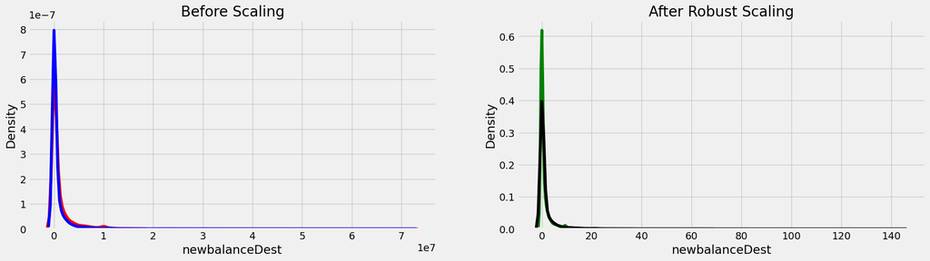

```python
import matplotlib.pyplot as plt
import seaborn as sns

# Assuming you have train_x, train_y, test_new_dfX, and test_new_dfY defined
fig, (ax1, ax2) = plt.subplots(ncols=2, figsize=(20, 5))

# Plotting the KDE plot for 'type' before scaling
sns.kdeplot(train_x['newbalanceDest'], ax=ax1, color='r')
ax1.set_title('Before Scaling')

# Plotting the KDE plot for 'x2' after robust scaling
sns.kdeplot(train_x['oldbalanceDest'], ax=ax1, color='b')

ax2.set_title('After Robust Scaling')
sns.kdeplot(robust_df['newbalanceDest'], ax = ax2, color ='green')
sns.kdeplot(robust_df['oldbalanceDest'], ax = ax2, color ='black',)
plt.show()
```

```python
trainX_scaler
```

```
array([[ 1.32258065, -1.        ,  0.82490791,  0.        , -0.11204866,
         0.        ],
       [ 0.81048387,  0.        , -0.29158702,  3.15481469,  1.39452555,
         0.        ],
       [ 1.22177419, -1.        , 19.73318786,  0.        , -0.11204866,
         0.        ],
       ...,
       [ 0.71774194, -1.        ,  1.40844604,  0.        , -0.11204866,
         0.        ],
       [ 1.41129032,  0.        ,  0.46886987,  1.41610064,  0.93426535,
         0.        ],
       [ 1.04032258,  0.        , -0.12962277,  0.57999379,  0.26126087,
         0.        ]])
```

```python
testX_scaler
```

```
array([[-2.05645161e-01, -2.00000000e+00, -3.25136765e-01,
         0.00000000e+00, -1.12048657e-01,  0.00000000e+00],
       [-1.00806452e+00,  0.00000000e+00,  3.56702973e-01,
         1.21767072e+00,  1.00102132e+00,  0.00000000e+00],
       [-3.62903226e-02,  0.00000000e+00,  1.04228324e-01,
         2.48517085e+01,  1.17688268e+01,  0.00000000e+00],
       ...,
       [-9.91935484e-01, -2.00000000e+00, -3.26031213e-01,
         0.00000000e+00, -1.12048657e-01,  0.00000000e+00],
       [ 2.86290323e-01, -2.00000000e+00, -2.99204225e-01,
         0.00000000e+00, -1.12048657e-01,  0.00000000e+00],
       [-9.27419355e-01,  0.00000000e+00, -1.46049901e-01,
         5.76176308e-02,  8.25719600e-03,  0.00000000e+00]])
```

# TRAINING AND EVALUATING MODEL

Using the Logistic Regression, Ths can be used for fraud detection, Disease prediction or churn prediction

```python
from sklearn.linear_model import LogisticRegression
```

```python
logReg_model = LogisticRegression()
```

```python
logReg_model.fit(trainX_scaler, train_y)
```

```
LogisticRegression()
```

METRIC AND ACCURACY

```python
#TO TEST THE ACCURACY OF THE MODEL
from sklearn.metrics import accuracy_score
```

```python
from sklearn.metrics import accuracy_score, precision_score, recall_score, f1_score, roc_auc_score, confusion_matrix
pred_y = logReg_model.predict(testX_scaler)
f1 = f1_score(test_new_dfY.values, pred_y)
roc_auc = roc_auc_score(test_new_dfY.values, pred_y)
conf_matrix = confusion_matrix(test_new_dfY.values, pred_y)
```

```python
print("-----------------------------------------")

print(f"Accuracy :{accuracy_score(test_new_dfY.values, pred_y)*100}%")

print("-----------------------------------------")

print("-----------------------------------------")
print(f'F1 Score: {f1}')
print("-----------------------------------------")

print("-----------------------------------------")
print(f'ROC AUC: {roc_auc}')
print("-----------------------------------------")

print("-----------------------------------------")
print(f'Confusion Matrix:\n{conf_matrix}')
print("-----------------------------------------")
```

```
-----------------------------------------
Accuracy :77.51065124771759%
-----------------------------------------
-----------------------------------------
F1 Score: 0.746483704974271
-----------------------------------------
-----------------------------------------
ROC AUC: 0.7751065124771759
-----------------------------------------
-----------------------------------------
Confusion Matrix:
[[1459  184]
 [ 555 1088]]
-----------------------------------------
```

Using Random forest Classifier

```python
from sklearn.ensemble import RandomForestClassifier
```

```python
randFor_model = RandomForestClassifier()
```

```python
randFor_model.fit(trainX_scaler, train_y)
```

```
RandomForestClassifier()
```

```python
from sklearn.metrics import accuracy_score, precision_score, recall_score, f1_score, roc_auc_score, confusion_matrix
pred_y = randFor_model.predict(testX_scaler)
f1 = f1_score(test_new_dfY.values, pred_y)
roc_auc = roc_auc_score(test_new_dfY.values, pred_y)
conf_matrix = confusion_matrix(test_new_dfY.values, pred_y)
```

```python
print("-----------------------------------------")

print(f"Accuracy :{accuracy_score(test_new_dfY.values, pred_y)*100}%")

print("-----------------------------------------")

print("-----------------------------------------")
print(f'F1 Score: {f1}')
print("-----------------------------------------")

print("-----------------------------------------")
print(f'ROC AUC: {roc_auc}')
print("-----------------------------------------")

print("-----------------------------------------")
print(f'Confusion Matrix:\n{conf_matrix}')
print("-----------------------------------------")
```

```
-----------------------------------------
Accuracy :91.60073037127206%
-----------------------------------------
-----------------------------------------
F1 Score: 0.9138038725796378
-----------------------------------------
-----------------------------------------
ROC AUC: 0.9160073037127207
-----------------------------------------
-----------------------------------------
Confusion Matrix:
[[1547   96]
 [ 180 1463]]
-----------------------------------------
```